# 02_kaggle(titanic)

#### 4-9 (추가) 나이와 남성,여성 정보를 나누고, 클래별 생존자 영향을 살펴보자.

```python
train_male = train[train['Sex']=="male"]
train_female = train[train['Sex']=="female"]

# 남성 1등석
train_male_pclass1 = train_male[train_male['Pclass']==1]
# 남성 2등석
train_male_pclass2 = train_male[train_male['Pclass']==2]
# 남성 3등석
train_male_pclass3 = train_male[train_male['Pclass']==3]

# 여성 1등석
train_female_pclass1 = train_female[train_female['Pclass']==1]
# 여성 2등석
train_female_pclass2 = train_female[train_female['Pclass']==2]
# 여성 3등석
train_female_pclass3 = train_female[train_female['Pclass']==3]
```

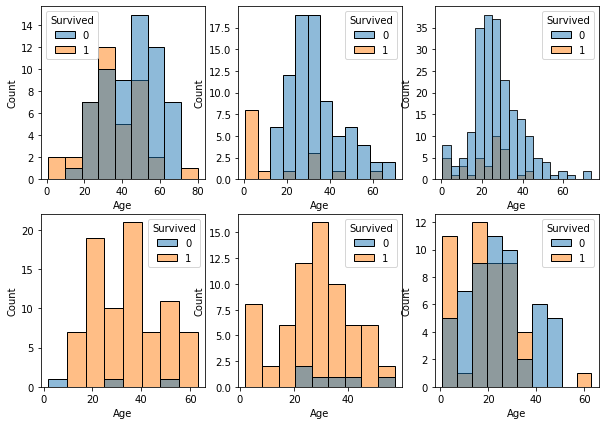

```python
# 남성의 클래스 별 생존률(그래프 여러개 출력)
plt.figure(figsize=(10,7))

# plt.subplot(행 개수,열 개수,배치 순서)
# 남성의 클래스 별 생존률
plt.subplot(2,3,1)
sns.histplot(x='Age', hue='Survived', data=train_male_pclass1)

plt.subplot(2,3,2)
sns.histplot(x='Age', hue='Survived', data=train_male_pclass2)

plt.subplot(2,3,3)
sns.histplot(x='Age', hue='Survived', data=train_male_pclass3)

# 여성의 클래스 별 생존률
plt.subplot(2,3,4)
sns.histplot(x='Age', hue='Survived', data=train_female_pclass1)

plt.subplot(2,3,5)
sns.histplot(x='Age', hue='Survived', data=train_female_pclass2)

plt.subplot(2,3,6)
sns.histplot(x='Age', hue='Survived', data=train_female_pclass3)
```

- 전체적으로 여성의 생존률이 높다
- 1등석으로 갈수록 생존률이 높다.

```python
# 01 Embarked의 영향
# 02 Fare의 요금 영향
```

#### 01 Embarked의 영향

```python
## sns.countplot : 막대그래프(x축 존재, y(데이터 개수))
## sns.boxplot : 박스 플룻, 쵀대값, 최소값, 중앙값, 이상치, 12%, 75%
## sns.lmplot(x='', y='', data=__) : 산점도의 경향성을 선형 그래프로 보여준다.
## sns.lmplot(x='', y='', data=__)
## sns.pairplot() : 그래프 여러개(하나의 변수와 다른 변수의 상관관계보기)
## sns.heatmap() : 항목별 도수에 따라 색깔을 다르게 표현
## sns.histplot() : 히스토그램(수치형 컬럼에 대한 분포 등을 확인)
## sns.barplot() : 막대그래프(x는 범주형, y는 그 값의 평균)
```

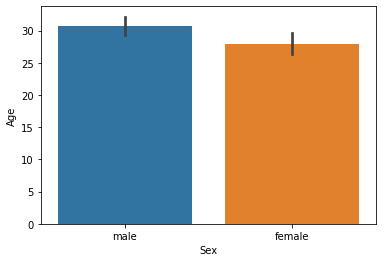

```python
sns.barplot(x='Sex', y='Age', data=train) # 각 항목별 평균을 막대그래프로 표현
```

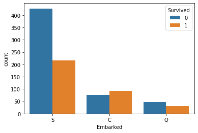

```python
sns.countplot(x='Embarked', hue='Survived', data=train)
```

- 승선 항구가 S인 사람들이 가장 많고 생존률이 세 항구 중 가장 낮다.
- c 항구 승선 사람의 생존률이 가장 높다.
- S항구 생존자가 많다.
- C항구의 생존자 비율이 높다. 왜?

```python
# my sol.
train_port_c = train[train["Embarked"]=="C"]
train_port_s = train[train["Embarked"]=="S"]
train_port_q = train[train["Embarked"]=="Q"]
train_port_c.head()
```

|  | PassengerId | Survived | Pclass | Name | Sex | Age | SibSp | Parch | Ticket | Fare | Cabin | Embarked |
| --- | --- | --- | --- | --- | --- | --- | --- | --- | --- | --- | --- | --- |
| 1 | 2 | 1 | 1 | Cumings, Mrs. John Bradley (Florence Briggs Th... | female | 38.0 | 1 | 0 | PC 17599 | 71.2833 | C85 | C |
| 9 | 10 | 1 | 2 | Nasser, Mrs. Nicholas (Adele Achem) | female | 14.0 | 1 | 0 | 237736 | 30.0708 | NaN | C |
| 19 | 20 | 1 | 3 | Masselmani, Mrs. Fatima | female | NaN | 0 | 0 | 2649 | 7.2250 | NaN | C |
| 26 | 27 | 0 | 3 | Emir, Mr. Farred Chehab | male | NaN | 0 | 0 | 2631 | 7.2250 | NaN | C |
| 30 | 31 | 0 | 1 | Uruchurtu, Don. Manuel E | male | 40.0 | 0 | 0 | PC 17601 | 27.7208 | NaN | C |

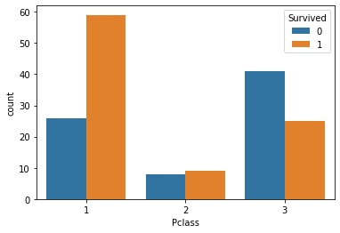

```python
sns.countplot(x='Pclass', hue='Survived', data=train_port_c)
```

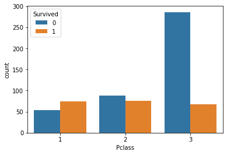

```python
sns.countplot(x='Pclass', hue='Survived', data=train_port_s)
```

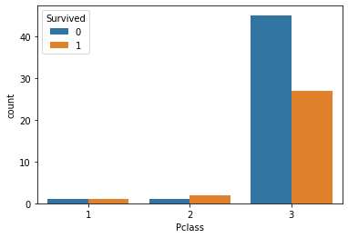

```python
sns.countplot(x='Pclass', hue='Survived', data=train_port_q)
```

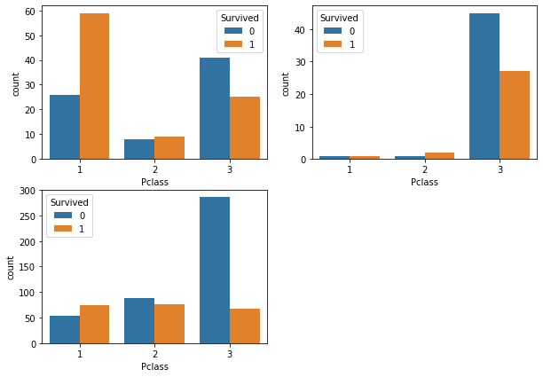

```python
# sol.

train_C = train[train['Embarked']=='C']   # 데이터에서 Embarked:C만 가져오기
train_Q = train[train['Embarked']=='Q']   # 데이터에서 Embarked:Q만 가져오기
train_S = train[train['Embarked']=='S']   # 데이터에서 Embarked:S만 가져오기

# 여러 그래프 한번에 출력
plt.figure(figsize=(10,7))
plt.subplot(2,2,1)
sns.countplot(x='Pclass', hue='Survived', data=train_C)

plt.subplot(2,2,2)
sns.countplot(x='Pclass', hue='Survived', data=train_Q)

plt.subplot(2,2,3)
sns.countplot(x='Pclass', hue='Survived', data=train_S)
```

- c 항구의 탑승자가 다른 항구에 비해 1등급 승객의 비율이 높았다.

#### 6-2 (추가) Fare에 대해 분석해 보기 - 댓글

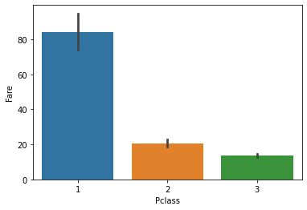

```python
sns.barplot(x='Pclass', y='Fare', data=train)
```

- 1등석의 평균 가격 : 80 정도
- 2등석의 평균 가격 : 20 정도
- 3등석의 평균 가격 : 15 정도

#### 6-3 (추가) Fare-Age에 대해 알아보기 - 댓글

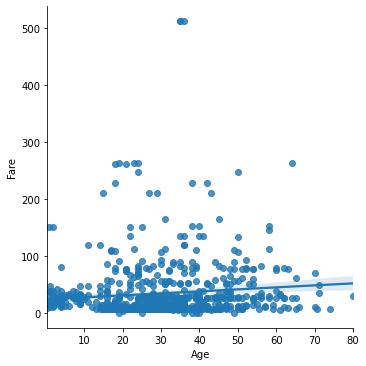

```python
sns.lmplot(x='Age', y='Fare', data=train, height=5)
```

- 나이가 많을 수록 요금도 상승하는 경향이 보이나 이산값이 많다.
  - 클래스별 나이와 요금 관계를 보는 것이 더 정확 할것 같다.

```python
# 클래스 별 자료 나누기
train_p1 = train[train['Pclass']==1]   # 데이터에서 Pclass:1만 가져오기
train_p2 = train[train['Pclass']==2]   # 데이터에서 Pclass:2만 가져오기
train_p3 = train[train['Pclass']==3]   # 데이터에서 Pclass:3만 가져오기
```

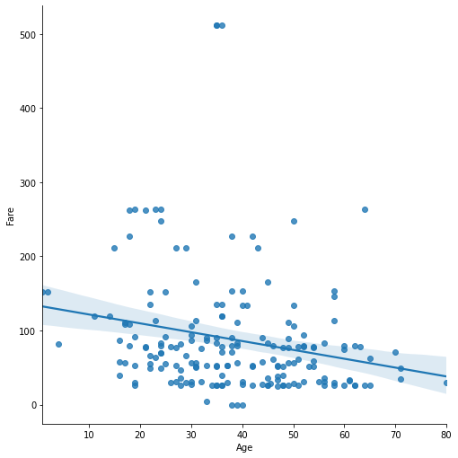

```python
sns.lmplot(x='Age', y='Fare', data=train_p1, height=7)
```

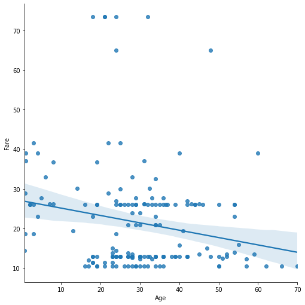

```python
sns.lmplot(x='Age', y='Fare', data=train_p2, height=7)
```

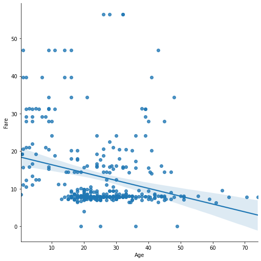

```python
sns.lmplot(x='Age', y='Fare', data=train_p3, height=7)
```

[figure not shown]

[figure not shown]

[figure not shown]

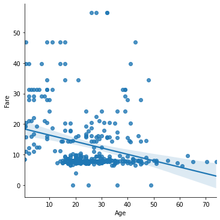

```python
# 클래스 별 자료 나누기
train_p1 = train[train['Pclass']==1]   # 데이터에서 Pclass:1만 가져오기
train_p2 = train[train['Pclass']==2]   # 데이터에서 Pclass:2만 가져오기
train_p3 = train[train['Pclass']==3]   # 데이터에서 Pclass:3만 가져오기

plt.figure(figsize=(10, 7))

plt.subplot(2,2,1)
sns.lmplot(x='Age', y='Fare', data=train_p1)

plt.subplot(2,2,2)
sns.lmplot(x='Age', y='Fare', data=train_p2)

plt.subplot(2,2,3)
sns.lmplot(x='Age', y='Fare', data=train_p3)
```

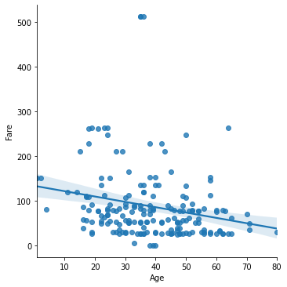

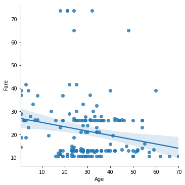

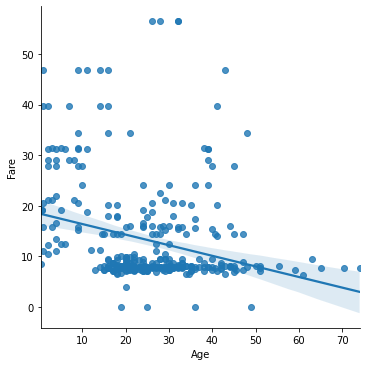

```python
# 클래스 별 자료 나누기
train_p1 = train[train['Pclass']==1]   # 데이터에서 Pclass:1만 가져오기
train_p2 = train[train['Pclass']==2]   # 데이터에서 Pclass:2만 가져오기
train_p3 = train[train['Pclass']==3]   # 데이터에서 Pclass:3만 가져오기

plt.figure(figsize=(10, 7))

sns.lmplot(x='Age', y='Fare', data=train_p1)
sns.lmplot(x='Age', y='Fare', data=train_p2)
sns.lmplot(x='Age', y='Fare', data=train_p3)
```